# Most Harmful Storm Data Events for Health and Economic Consequences

August 22, 2015

## Synopsis

This report performs an analysis of [NOAA Storm Event Data](https://d396qusza40orc.cloudfront.net/repdata%2Fdata%2FStormData.csv.bz2) that has 902,297 storm event observations for 37 variables. Documentation for the storm data can be found [here](https://d396qusza40orc.cloudfront.net/repdata%2Fpeer2_doc%2Fpd01016005curr.pdf). The analysis uses 7 variables from the data set to determine which storm events cause the most fatalities and injuries to people and the most economic damage with respect to property and crops.  
The data for the analysis was processed to consolidate common weather event types and for damage exponent data that is applied to property and crop base damage amounts. The results will show that tornados, heat and flooding are the top three weather events that are most fatal to people. In terms of economic damage flood, hurricane and tornado were the most costly.

## Data Processing

### Loading the data

The steps for loading the data are as follows:

1. Create a **data** folder in the working directory if one does not already exist.
2. If the the storm data csv file does not exist then download the zip file and unzip it.
3. Load the data into a variable named **stormData**.

```r
## Make sure a folder exists for the data
if (!file.exists("data")){
    dir.create("data")
}

## Download the zip file if the csv file does not exist
if (!file.exists("data/repdata-data-StormData.csv"))
{
    ## Download the zipfile and unzip
    library(R.utils)
    download.file("https://d396qusza40orc.cloudfront.net/repdata%2Fdata%2FStormData.csv.bz2", "data/repdata-data-StormData.csv.bz2", method="curl")
    bunzip2(filename = "data/repdata-data-StormData.csv.bz2")
}

stormData <- read.csv("data/repdata-data-StormData.csv")
```

### Select the subset of the data we need to examine

Our analysis asks us to answer two questions with respect to weather events.

1. Across the United States, which types of events (as indicated in the EVTYPE variable) are **most harmful with respect to population health**?
2. Across the United States, which types of events have the **greatest economic consequences**?

To answer these questions we will need to examine the follow variables from the Storm Data:

- EVTYPE - The event type (Tornado, Thunderstorm, …)
- FATALITIES - The number of fatalities for a weather event observation.
- INJURIES - The number of injuries for a weather event observation.
- PROPDMG - The base amount in USD for property damage.
- PROPDMGEXP - Exponent code applied to base property damage amount. (e.g., 5.0 K = $5,000)
- CROPDMG - The base amount in USD for crop damage.
- CROPDMGEXP - Exponent code applied to base property damage amount. (e.g., 5.0 < = $5,000,000)

```r
## Identify the variable we want to keep
keepVars <- c("EVTYPE", "FATALITIES", "INJURIES", "PROPDMG", "PROPDMGEXP", "CROPDMG", "CROPDMGEXP")

## Slice the Storm Data down to the variable that we need
stormData <- stormData[keepVars]
```

### Cleaning up the data

The data needs to be cleaned with respect to the Event Types and the Property and Crop Damage Exponents. Refer to the corresponding sections below.

#### Cleaning up event types

There are 985 different event types. For this analysis we are only concerned about harmful events where there were fatalities, injuries, property or crop damage. For that subset of data there are 488 different event types as shown by the code below.

```r
length(unique(stormData$EVTYPE))
```

```
## [1] 985
```

```r
harmfulEvents <- sort(unique(stormData[stormData$FATALITIES > 0 | stormData$INJURIES > 0 |
              stormData$PROPDMG > 0 | stormData$CROPDMG > 0,]$EVTYPE))
length(harmfulEvents)
```

```
## [1] 488
```

Of the 488 harmful events many are misspelled or in a different case and most have a different event type for the same type of event or event category. I will consolidate the events with the following processing:

1. Trim the event types and convert all to uppercase.
2. Group event types for the following type of events: Cold, Heat, Snow, Tornado, Thunderstorm, Hurricane, Avalanche, Floods, High Winds, Lightning, and Mud Slides.

```r
library(R.utils, quietly = TRUE)

## Trim and convert to uppercase
stormData$EVTYPE <- toupper(trim(stormData$EVTYPE))

## Group event types
stormData$EVTYPE[grep("MUD",stormData$EVTYPE)] = "MUD"
stormData$EVTYPE[grep("AVALAN",stormData$EVTYPE)] = "AVALANCHE"
stormData$EVTYPE[grep("HEAT",stormData$EVTYPE)] = "HEAT"
stormData$EVTYPE[grep("COLD",stormData$EVTYPE)] = "COLD"
stormData$EVTYPE[grep("SNOW",stormData$EVTYPE)] = "SNOW"
stormData$EVTYPE[grep("HIGH WIND",stormData$EVTYPE)] = "HIGH WIND"
stormData$EVTYPE[grep("LIGHTNING",stormData$EVTYPE)] = "LIGHTNING"
stormData$EVTYPE[grep("FLOOD",stormData$EVTYPE)] = "FLOOD"
stormData$EVTYPE[grep("HURRICANE",stormData$EVTYPE)] = "HURRICANE"
stormData$EVTYPE[grep("TROPICAL STORM",stormData$EVTYPE)] = "TROPICAL STORM"
stormData$EVTYPE[grep("TORNADO",stormData$EVTYPE)] = "TORNADO"
stormData$EVTYPE[c(grep("THUNDERSTORM",stormData$EVTYPE),
                   grep("^TSTM",stormData$EVTYPE))] = "THUNDERSTORM"
```

Now we are down to a more reasonable 205 harmful events.

```r
harmfulEvents <- sort(unique(stormData[stormData$FATALITIES > 0 | stormData$INJURIES > 0 |
              stormData$PROPDMG > 0 | stormData$CROPDMG > 0,]$EVTYPE))
length(harmfulEvents)
```

```
## [1] 205
```

#### Cleaning the Property and Crop Damage Exponents

I could not find a code book for the NOAA Storm Data that discussed property and crop damage codes but based on the [Storm Data Documentation](https://d396qusza40orc.cloudfront.net/repdata%2Fpeer2_doc%2Fpd01016005curr.pdf) damage amounts were listed in the examples as 50K or 2.5M I believe the valid codes are as follows:

- B or b - Billions (damage amount x 10<sup>9</sup>)
- M or m - Millions (damage amount x 10<sup>6</sup>)
- K or k - Thousands (damage amount x 10<sup>3</sup>)
- H or h - Hundreds (damage amount x 10<sup>2</sup>)

Any exponent codes that do not fall into the above codes will be changed to an exponent of 0 (base damage amount x 10<sup>0</sup> = base damage amount x 1).

Let’s check the scope of the data that does **not** have “good” exponents.

```r
## Define a list of good exponent codes
goodExp = c("h", "H", "k", "K", "m", "M", "b", "B")


## All property damage values > 0 with bad codes
badPropertyDamage <-
    stormData[!(stormData$PROPDMGEXP %in% goodExp) & stormData$PROPDMG != 0,]$PROPDMG

## All crop damage values > 0 with bad codes
badCropDamage <-
    stormData[!(stormData$CROPDMGEXP %in% goodExp) & stormData$CROPDMG != 0,]$CROPDMG
```

Total observation count effected by bad codes for property and crop damage is only 335 out of nearly 1 million observations.

```r
c(length(badPropertyDamage), length(badCropDamage))
```

```
## [1] 320  15
```

A summary of the damage data effected by bad exponent codes.

```r
## Summary of bad property damage
summary(badPropertyDamage)
```

```
##    Min. 1st Qu.  Median    Mean 3rd Qu.    Max.
##    0.10    5.00   15.00   25.54   50.00  150.00
```

```r
## Summary of bad crop damage
summary(badCropDamage)
```

```
##    Min. 1st Qu.  Median    Mean 3rd Qu.    Max.
##    3.00    5.00    5.00   18.07   25.00   60.00
```

```r
## List the unique Property Damage Exponents
unique(stormData$PROPDMGEXP)
```

```
##  [1] K M   B m + 0 5 6 ? 4 2 3 h 7 H - 1 8
## Levels:  - ? + 0 1 2 3 4 5 6 7 8 B h H K m M
```

```r
## List the unique Crop Damage Exponents
unique(stormData$CROPDMGEXP)
```

```
## [1]   M K m B ? 0 k 2
## Levels:  ? 0 2 B k K m M
```

The property and crop damage exponents will be cleaned as follows:

1. Convert all exponents to uppercase.
2. Convert all bad exponents to a base multiplier of 1.
3. Convert all “B” expoents to a base multiplier of 10<sup>9</sup>.
4. Convert all “M” expoents to a base multiplier of 10<sup>6</sup>.
5. Convert all “K” expoents to a base multiplier of 10<sup>3</sup>.
6. Convert all “H” expoents to a base multiplier of 10<sup>2</sup>.
7. Compute a PropertyDamage variable = base amount * multiplier.
8. Compute a CropDamage variable = base amount * multiplier.
9. Compute a TotalDamage variable = PropertyDamage + CropDamage.

```r
## Convert all exponents to uppercase.
stormData$PROPDMGEXP <- toupper(stormData$PROPDMGEXP)
stormData$CROPDMGEXP <- toupper(stormData$CROPDMGEXP)

## Convert all bad exponents to a base multiplier of 1.
##... Create a DamageMultiplier that will be update for all except bad exponents.
stormData$PropertyDamageMultiplier <- 1
stormData$CropDamageMultiplier <- 1

## Convert all "B" expoents to a base multiplier of 10^9^.
stormData[stormData$PROPDMGEXP == "B",]$PropertyDamageMultiplier <- 10^9
stormData[stormData$CROPDMGEXP == "B",]$CropDamageMultiplier <- 10^9

## Convert all "M" expoents to a base multiplier of 10^6^.
stormData[stormData$PROPDMGEXP == "M",]$PropertyDamageMultiplier <- 10^6
stormData[stormData$CROPDMGEXP == "M",]$CropDamageMultiplier <- 10^6

## Convert all "K" expoents to a base multiplier of 10^3^.
stormData[stormData$PROPDMGEXP == "K",]$PropertyDamageMultiplier <- 10^3
stormData[stormData$CROPDMGEXP == "K",]$CropDamageMultiplier <- 10^3

## Convert all "H" expoents to a base multiplier of 10^2^.
stormData[stormData$PROPDMGEXP == "H",]$PropertyDamageMultiplier <- 10^2
## There is no "H" exponent for crops.

## Compute a PropertyDamage variable = base amount * multiplier.
stormData$PropertyDamage <- stormData$PROPDMG * stormData$PropertyDamageMultiplier

## Compute a CropDamage variable = base amount * multiplier.
stormData$CropDamage <- stormData$CROPDMG * stormData$CropDamageMultiplier
```

## Results

### Fatalities and Injuries by Weather Event Type

When determining what type of weather event is the most harmful to people the data could be sorted by fatalities, injuries or a combined total. A review of the data below sorted by fatalities and again by injuries shows that both top 10 lists are very close. The top 5 have the same events with a different order, i.e., a higher death toll correlates to higher injury rates.

```r
fatalitiesByEvent <- aggregate.data.frame(
    list(TotalFatalities = stormData$FATALITIES, TotalInjuries = stormData$INJURIES),
    list(EventType = stormData$EVTYPE),
    sum, na.rm = TRUE )
fatalitiesByEvent <- fatalitiesByEvent[!(fatalitiesByEvent$TotalInjuries == 0 &
                                         fatalitiesByEvent$TotalFatalities == 0),]
fatalitiesByEvent$Total <- fatalitiesByEvent$TotalInjuries + fatalitiesByEvent$TotalFatalities

## Sort by Total Fatalities
fatalitiesByEvent <- fatalitiesByEvent[order(-fatalitiesByEvent$TotalFatalities),]
head(fatalitiesByEvent, n=10)
```

```
##        EventType TotalFatalities TotalInjuries Total
## 381      TORNADO            5661         91407 97068
## 149         HEAT            3138          9224 12362
## 82         FLOOD            1525          8604 10129
## 212    LIGHTNING             817          5232  6049
## 374 THUNDERSTORM             720          9534 10254
## 31          COLD             451           320   771
## 274  RIP CURRENT             368           232   600
## 181    HIGH WIND             294          1476  1770
## 9      AVALANCHE             225           171   396
## 453 WINTER STORM             206          1321  1527
```

```r
## Sort by Total Injuries
fatalitiesByEvent <- fatalitiesByEvent[order(-fatalitiesByEvent$TotalInjuries),]
head(fatalitiesByEvent, n=10)
```

```
##        EventType TotalFatalities TotalInjuries Total
## 381      TORNADO            5661         91407 97068
## 374 THUNDERSTORM             720          9534 10254
## 149         HEAT            3138          9224 12362
## 82         FLOOD            1525          8604 10129
## 212    LIGHTNING             817          5232  6049
## 199    ICE STORM              89          1975  2064
## 181    HIGH WIND             294          1476  1770
## 119         HAIL              15          1361  1376
## 187    HURRICANE             133          1328  1461
## 453 WINTER STORM             206          1321  1527
```

Since death is a more serious than injury (you can’t come back from death) the data is going to be sorted by fataities and ploted.

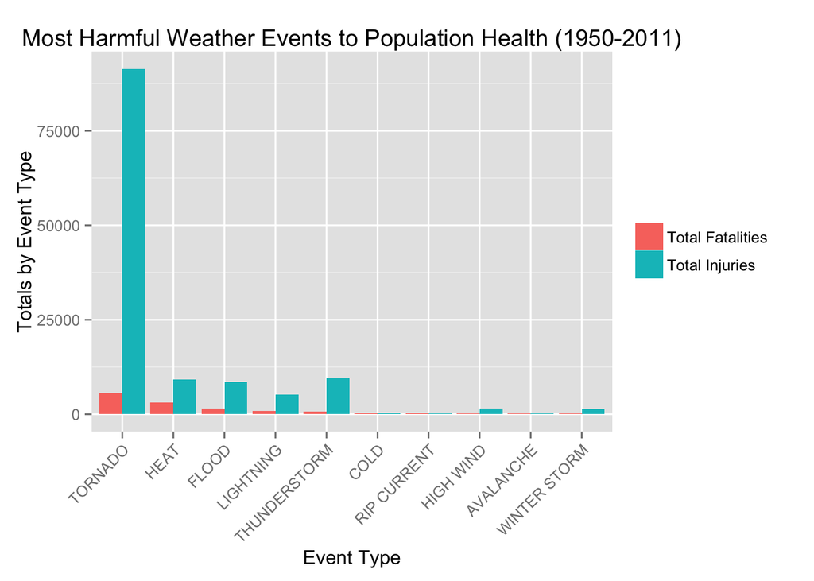

```r
library(reshape2)
library(ggplot2)
## Get the Top 10 sorted by fatalities
fatalitiesByEvent <- fatalitiesByEvent[order(-fatalitiesByEvent$TotalFatalities),]
top10Fatalities <- fatalitiesByEvent[1:10,]

## Melt the data for plotting
meltTop10 <- melt(top10Fatalities[,c("EventType","TotalFatalities","TotalInjuries")],id.vars = c("EventType"))

## Set factor to effect event type order by value
meltTop10$EventType <- factor(meltTop10$EventType,levels=unique(meltTop10$EventType))

## Show the plot
ggplot(meltTop10,aes(x = EventType, y = value, fill=variable)) +
    geom_bar(position = "dodge", stat="identity", binwidth=1) +
    ggtitle("Most Harmful Weather Events to Population Health (1950-2011)") +
    labs(x = "Event Type", y = "Totals by Event Type") +
    theme(axis.text.x=element_text(angle=45,hjust=1)) +
    scale_fill_discrete(name="",
                         breaks=c("TotalFatalities", "TotalInjuries"),
                         labels=c("Total Fatalities", "Total Injuries"))
```

By far the most harmful weather event to people is **tornados** followed by heat and flooding.

### Property and Crop Damage Amounts by Weather Event Type

Group the property and crop damage by weather event type.

```r
damageByEvent <- aggregate.data.frame(
    list(PropertyDamage = stormData$PropertyDamage, CropDamage = stormData$CropDamage),
    list(EventType = stormData$EVTYPE),
    sum, na.rm = TRUE )
damageByEvent <- damageByEvent[!(damageByEvent$PropertyDamage == 0 &
                                 damageByEvent$CropDamage == 0),]
damageByEvent$TotalDamage <- damageByEvent$PropertyDamage + damageByEvent$CropDamage
```

Sort results by Property Damage and review the top 10.

```r
damageByEvent <- damageByEvent[order(-damageByEvent$PropertyDamage),]
head(damageByEvent, n=10)
```

```
##          EventType PropertyDamage  CropDamage  TotalDamage
## 82           FLOOD   167518185932 12380089100 179898275032
## 187      HURRICANE    84656180010  5505292800  90161472810
## 381        TORNADO    58593097979   417461470  59010559449
## 299    STORM SURGE    43323536000        5000  43323541000
## 119           HAIL    15732267543  3025954473  18758222016
## 374   THUNDERSTORM    10969851156  1271673988  12241525144
## 386 TROPICAL STORM     7714390550   694896000   8409286550
## 453   WINTER STORM     6688497251    26944000   6715441251
## 181      HIGH WIND     6054000053   694801900   6748801953
## 441       WILDFIRE     4765114000   295472800   5060586800
```

Sort results by Crop Damage and review the top 10.

```r
damageByEvent <- damageByEvent[order(-damageByEvent$CropDamage),]
head(damageByEvent, n=10)
```

```
##        EventType PropertyDamage  CropDamage  TotalDamage
## 43       DROUGHT     1046106000 13972566000  15018672000
## 82         FLOOD   167518185932 12380089100 179898275032
## 187    HURRICANE    84656180010  5505292800  90161472810
## 199    ICE STORM     3944927860  5022113500   8967041360
## 119         HAIL    15732267543  3025954473  18758222016
## 31          COLD      246579450  1416765550   1663345000
## 374 THUNDERSTORM    10969851156  1271673988  12241525144
## 96  FROST/FREEZE       10480000  1094186000   1104666000
## 149         HEAT       20325750   904469280    924795030
## 153   HEAVY RAIN      694248090   733399800   1427647890
```

Sort results by Total Damage and review the top 10.

```r
damageByEvent <- damageByEvent[order(-damageByEvent$TotalDamage),]
head(damageByEvent, n=10)
```

```
##          EventType PropertyDamage  CropDamage  TotalDamage
## 82           FLOOD   167518185932 12380089100 179898275032
## 187      HURRICANE    84656180010  5505292800  90161472810
## 381        TORNADO    58593097979   417461470  59010559449
## 299    STORM SURGE    43323536000        5000  43323541000
## 119           HAIL    15732267543  3025954473  18758222016
## 43         DROUGHT     1046106000 13972566000  15018672000
## 374   THUNDERSTORM    10969851156  1271673988  12241525144
## 199      ICE STORM     3944927860  5022113500   8967041360
## 386 TROPICAL STORM     7714390550   694896000   8409286550
## 181      HIGH WIND     6054000053   694801900   6748801953
```

The above results show that there are some weather events that can greatly effect property or crops but not both. For example when sorting by property damage tornadoes are in the top 3 but does not make the top 10 when sorted by crop damage.

When the list is sorted by total damage the top 10 shows events that have impacts on property and crops. For this reason the top 10 shown in the plot below are sorted by the total combined property and crop damage.

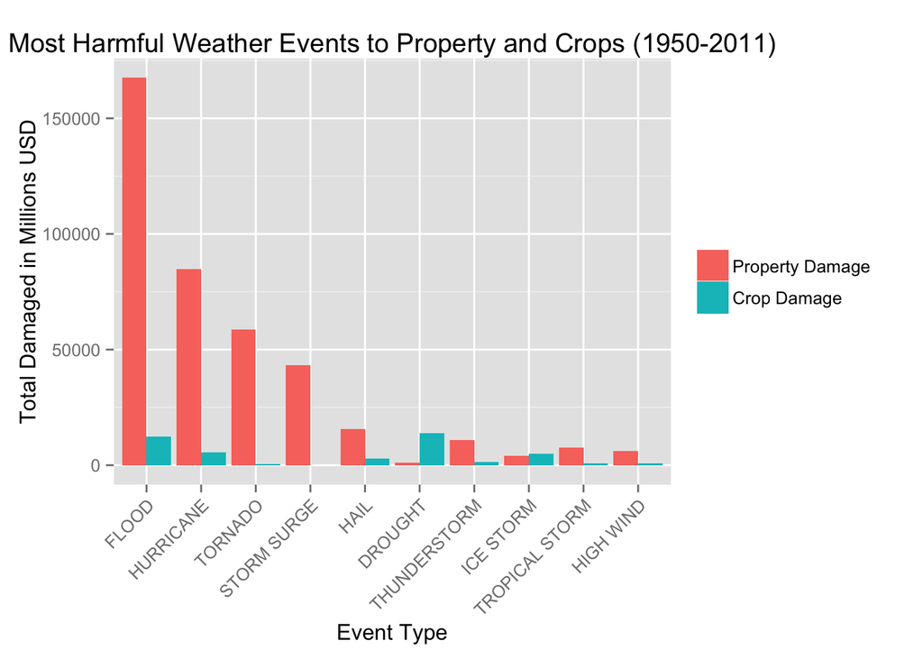

```r
## Get the top 10 damage results sorted by total damages.
damageByEvent <- damageByEvent[order(-damageByEvent$TotalDamage),]
top10Damage <- damageByEvent[1:10,1:3]

## Convert dollar amounts to millions (M) for display purposes
top10Damage$PropertyDamage <- top10Damage$PropertyDamage / 10^6
top10Damage$CropDamage <- top10Damage$CropDamage / 10^6

## Melt the data for plotting
meltTop10Damage <- melt(top10Damage[,c("EventType","PropertyDamage","CropDamage")],
                        id.vars = c("EventType"))

## Set factor to effect event type order by value
meltTop10Damage$EventType <- factor(meltTop10Damage$EventType,levels=unique(meltTop10Damage$EventType))

## Show the plot
ggplot(meltTop10Damage,aes(x = EventType, y = value, fill=variable)) +
    geom_bar(position = "dodge", stat="identity", binwidth=1) +
    ggtitle("Most Harmful Weather Events to Property and Crops (1950-2011)") +
    labs(x = "Event Type", y = "Total Damaged in Millions USD") +
    theme(axis.text.x=element_text(angle=45,hjust=1)) +
    scale_fill_discrete(name="",
                         breaks=c("PropertyDamage", "CropDamage"),
                         labels=c("Property Damage", "Crop Damage"))
```

In terms of economic effects **flooding** causes the most damage followed by hurricanes, tornados and storm surge.